# Mise en forme et ingénierie des données

Daniel Pont

08/06/2020

# Mise en forme et ingénierie des données

## 1. Sélection des données

### 1.1 Sous-ensemble des lignes et des colonnes

```r
library(ggplot2)
summary(iris)
```

```
##   Sepal.Length    Sepal.Width     Petal.Length    Petal.Width
##  Min.   :4.300   Min.   :2.000   Min.   :1.000   Min.   :0.100
##  1st Qu.:5.100   1st Qu.:2.800   1st Qu.:1.600   1st Qu.:0.300
##  Median :5.800   Median :3.000   Median :4.350   Median :1.300
##  Mean   :5.843   Mean   :3.057   Mean   :3.758   Mean   :1.199
##  3rd Qu.:6.400   3rd Qu.:3.300   3rd Qu.:5.100   3rd Qu.:1.800
##  Max.   :7.900   Max.   :4.400   Max.   :6.900   Max.   :2.500
##        Species
##  setosa    :50
##  versicolor:50
##  virginica :50
##
##
##
```

```r
head(iris)
```

```
##   Sepal.Length Sepal.Width Petal.Length Petal.Width Species
## 1          5.1         3.5          1.4         0.2  setosa
## 2          4.9         3.0          1.4         0.2  setosa
## 3          4.7         3.2          1.3         0.2  setosa
## 4          4.6         3.1          1.5         0.2  setosa
## 5          5.0         3.6          1.4         0.2  setosa
## 6          5.4         3.9          1.7         0.4  setosa
```

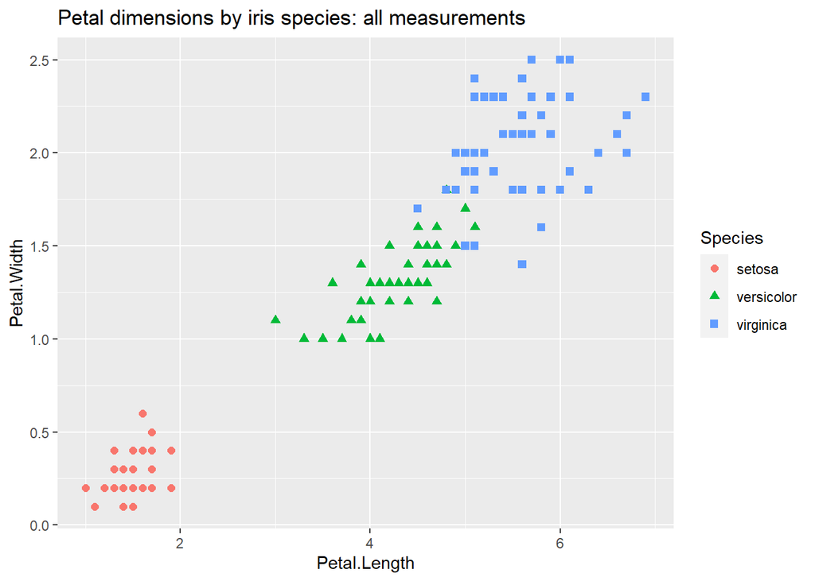

```r
ggplot(iris, aes(x=Petal.Length,y=Petal.Width,
                 shape= Species, color = Species)) +
    geom_point(size=2) +
    ggtitle("Petal dimensions by iris species: all measurements")
```

#### 1.1.1 Avec les méthodes de base en R

```r
columns_we_want <- c("Petal.Length", "Petal.Width", "Species")
rows_we_want <- iris$Petal.Length > 2

#AVANT
head(iris)
```

```
##   Sepal.Length Sepal.Width Petal.Length Petal.Width Species
## 1          5.1         3.5          1.4         0.2  setosa
## 2          4.9         3.0          1.4         0.2  setosa
## 3          4.7         3.2          1.3         0.2  setosa
## 4          4.6         3.1          1.5         0.2  setosa
## 5          5.0         3.6          1.4         0.2  setosa
## 6          5.4         3.9          1.7         0.4  setosa
```

```r
#APRES
#(drop=false permet d'obtenir un data.frame et non un vector si on ne sélectionne qu'une seule colonne)
iris_base <- iris[rows_we_want,columns_we_want,drop=FALSE]
head(iris_base)
```

```
##    Petal.Length Petal.Width    Species
## 51          4.7         1.4 versicolor
## 52          4.5         1.5 versicolor
## 53          4.9         1.5 versicolor
## 54          4.0         1.3 versicolor
## 55          4.6         1.5 versicolor
## 56          4.5         1.3 versicolor
```

#### 1.1.2 Avec une data.table

Quelques points clés sur les data.tables :

- ce sont des méthodes d’indexation puissantes (ex. : “..” ci-dessous)
- elles constitient la solution R la plus efficace en terme de rapidité et de de mémoire pour une large plage d’échelles
- FAQ : https://cran.r-project.org/web/packages/data.table/vignettes/datatable-faq.html
- Cheat sheet : https://www.datacamp.com/community/tutorials/data-table-cheat-sheet

```r
library(data.table)
iris_data.table <- as.data.table(iris)
columns_we_want <- c("Petal.Length", "Petal.Width", "Species")
rows_we_want <- iris$Petal.Length > 2
# .. indique que columns_we_want n'est pas un nom de colonne mais une varaible contenant les colonnes
iris_data.table <- iris_data.table[rows_we_want,..columns_we_want]
head(iris_data.table)
```

```
##    Petal.Length Petal.Width    Species
## 1:          4.7         1.4 versicolor
## 2:          4.5         1.5 versicolor
## 3:          4.9         1.5 versicolor
## 4:          4.0         1.3 versicolor
## 5:          4.6         1.5 versicolor
## 6:          4.5         1.3 versicolor
```

Pour mieux comprendre la notation “..”, voici un exemple :

```r
library(data.table)
df <- data.frame(x=1:2,y=3:4)
# ERREUR (x non défini) :
#df[,x]

#Fonctionnement avec une data.table :
dt <- data.table(df)
x <- "y"

# sélectionne la colonne "x"
dt[,x]
```

```
## [1] 1 2
```

```r
# sélectionne la colonne "y"
dt[,..x]
```

```
##    y
## 1: 3
## 2: 4
```

NB : Avec les packages qui ne les supportent pas, les data.tables se comportent comme des data.frames.

#### 1.1.3 Avec dplyr

Pour sélectionner :

- des *colonnes*, on utilise *dplyr::select*
- des *lignes*, on utilise *dplyr::filter*

```r
library(dplyr)

iris_dplyr <- iris %>%
                select( Petal.Length, Petal.Width, Species)  %>%
                filter( iris$Petal.Length > 2)
# NB : on peut aussi utiliser  select( c("Petal.Length", "Petal.Width", "Species"))

head(iris_dplyr)
```

```
##   Petal.Length Petal.Width    Species
## 1          4.7         1.4 versicolor
## 2          4.5         1.5 versicolor
## 3          4.9         1.5 versicolor
## 4          4.0         1.3 versicolor
## 5          4.6         1.5 versicolor
## 6          4.5         1.3 versicolor
```

### 1.2 Suppression des enregistrements avec des données manquantes

```r
library(ggplot2)
data(msleep)
str(msleep)
```

```
## tibble [83 x 11] (S3: tbl_df/tbl/data.frame)
##  $ name        : chr [1:83] "Cheetah" "Owl monkey" "Mountain beaver" "Greater short-tailed shrew" ...
##  $ genus       : chr [1:83] "Acinonyx" "Aotus" "Aplodontia" "Blarina" ...
##  $ vore        : chr [1:83] "carni" "omni" "herbi" "omni" ...
##  $ order       : chr [1:83] "Carnivora" "Primates" "Rodentia" "Soricomorpha" ...
##  $ conservation: chr [1:83] "lc" NA "nt" "lc" ...
##  $ sleep_total : num [1:83] 12.1 17 14.4 14.9 4 14.4 8.7 7 10.1 3 ...
##  $ sleep_rem   : num [1:83] NA 1.8 2.4 2.3 0.7 2.2 1.4 NA 2.9 NA ...
##  $ sleep_cycle : num [1:83] NA NA NA 0.133 0.667 ...
##  $ awake       : num [1:83] 11.9 7 9.6 9.1 20 9.6 15.3 17 13.9 21 ...
##  $ brainwt     : num [1:83] NA 0.0155 NA 0.00029 0.423 NA NA NA 0.07 0.0982 ...
##  $ bodywt      : num [1:83] 50 0.48 1.35 0.019 600 ...
```

```r
summary(msleep)
```

```
##      name              genus               vore              order
##  Length:83          Length:83          Length:83          Length:83
##  Class :character   Class :character   Class :character   Class :character
##  Mode  :character   Mode  :character   Mode  :character   Mode  :character
##
##
##
##
##  conservation        sleep_total      sleep_rem      sleep_cycle
##  Length:83          Min.   : 1.90   Min.   :0.100   Min.   :0.1167
##  Class :character   1st Qu.: 7.85   1st Qu.:0.900   1st Qu.:0.1833
##  Mode  :character   Median :10.10   Median :1.500   Median :0.3333
##                     Mean   :10.43   Mean   :1.875   Mean   :0.4396
##                     3rd Qu.:13.75   3rd Qu.:2.400   3rd Qu.:0.5792
##                     Max.   :19.90   Max.   :6.600   Max.   :1.5000
##                                     NA's   :22      NA's   :51
##      awake          brainwt            bodywt
##  Min.   : 4.10   Min.   :0.00014   Min.   :   0.005
##  1st Qu.:10.25   1st Qu.:0.00290   1st Qu.:   0.174
##  Median :13.90   Median :0.01240   Median :   1.670
##  Mean   :13.57   Mean   :0.28158   Mean   : 166.136
##  3rd Qu.:16.15   3rd Qu.:0.12550   3rd Qu.:  41.750
##  Max.   :22.10   Max.   :5.71200   Max.   :6654.000
##                  NA's   :27
```

#### 1.2.1 Avec les méthodes de base en R

Deux méthodes importantes :

- *complete.cases()* retourne un vecteur contant les indices des enregistrements sans donnée manquante
- *na.omit()* supprime les enregistrements avec des données manquantes

```r
clean_base1 <- msleep[complete.cases(msleep),,drop =FALSE]
nrow(clean_base1)
```

```
## [1] 20
```

```r
clean_base2 <- na.omit(msleep)
nrow(clean_base2)
```

```
## [1] 20
```

#### 1.2.2 Avec une data.table

la méthode *complete.cases()* fonctionne aussi avec une data.table

```r
library(data.table)

msleep_data.table <- as.data.table(msleep)
clean_data.table <- msleep_data.table[complete.cases(msleep_data.table),]
nrow(clean_data.table)
```

```
## [1] 20
```

#### 1.2.3 Avec dplyr

La méthode *complete.cases()* est utilisable avec *dplyr::filter()*.  
Avec le pipe magrittr (“%>%”) le “.” désigne l’élement qur lequel on applique le pipe. Dans l’exemple ci-dessous il s’agit donc à la fois des données auxquelles on applique le *filter()* que l’objet passé à la fonction *complet.cases()* :

```r
library(dplyr)

clean_dplyr  <- msleep %>%
                  filter( . , complete.cases(.))
nrow(clean_dplyr)
```

```
## [1] 20
```

### 1.3 Tri des lignes avec cumul simple

Dans l’exemple suivant, le but est de trier les “purchases” par “day” et “hour” pour calculer le cumul des achats.

```r
purchases <- wrapr::build_frame(
"day", "hour", "n_purchase" |
1 ,9 ,5 |
2 ,9 ,3 |
2 ,11 ,5 |
1 ,13 ,1 |
2 ,13 ,3 |
1 ,14 ,1 )
```

#### 1.3.1 Avec les méthodes de base en R

```r
order_index <- with(purchases,order(day,hour))
purchases_ordered <- purchases[order_index,,drop=FALSE]
purchases_ordered$running_total <- cumsum(purchases_ordered$n_purchase)
purchases_ordered
```

```
##   day hour n_purchase running_total
## 1   1    9          5             5
## 4   1   13          1             6
## 6   1   14          1             7
## 2   2    9          3            10
## 3   2   11          5            15
## 5   2   13          3            18
```

#### 1.3.2 Avec une data.table

```r
library(data.table)

DT_purchases <- as.data.table(purchases)
order_cols <- c("day","hour")
setorderv(DT_purchases,order_cols)
DT_purchases[,running_total := cumsum(n_purchase)]
# print(DT_purchases)
```

#### 1.3.3 Avec dplyr

```r
library(dplyr)

res <- purchases %>%
        arrange(.,day,hour) %>%
        mutate(.,running_total=cumsum(n_purchase))
```

### 1.4 Tri des lignes avec cumul par groupe

#### 1.4.1 Avec les méthodes de base en R

```r
order_index <- with(purchases,order(day,hour))
purchases_ordered <- purchases[order_index,,drop=FALSE]
data_list <- split(purchases_ordered,purchases_ordered$day)
data_list <- lapply(
                data_list,
                function(di){
                  di$running_total <- cumsum(di$n_purchase)
                  di
                }  )
purchases_ordered <- do.call(base::rbind,data_list)
rownames(purchases_ordered) <- NULL
purchases_ordered
```

```
##   day hour n_purchase running_total
## 1   1    9          5             5
## 2   1   13          1             6
## 3   1   14          1             7
## 4   2    9          3             3
## 5   2   11          5             8
## 6   2   13          3            11
```

#### 1.4.2 Avec une data.table

```r
library(data.table)


# creation d'une nouvelle copie pour le resultat
# ----------------------------------------------
DT_purchases <- as.data.table(purchases)[order(day,hour),
                                         .(hour=hour,
                                          n_purchase=n_purchase,
                                          running_total=cumsum(n_purchase)),
                                         by="day"
                                         ]
# print(DT_purchases)

# modification de la data.table existante
# ----------------------------------------------
DT_purchases <- as.data.table(purchases)
order_cols <- c("day","hour")
setorderv(DT_purchases,order_cols)
DT_purchases[,running_total:=cumsum(n_purchase),by=day]
#print(DT_purchases)

# conserve l'ordre des données initiales
# ----------------------------------------------
DT_purchases <- as.data.table(purchases)
DT_purchases[order(day,hour),
             `:=`(hour = hour,
                n_purchase = n_purchase,
                running_total = cumsum(n_purchase)),
            by = "day"]
#print(DT_purchases)
```

#### 1.4.3 Avec dplyr

```r
library(dplyr)

res <- purchases %>%
        arrange(.,day,hour) %>%
        group_by(.,day) %>%
        mutate(.,running_total=cumsum(n_purchase)) %>%
        ungroup(.)

#print(as.data.frame(res))
```

## 2. Transformations basiques de données

### 2.1 Ajout de nouvelles colonnes

On souhaite ajouter une nouvelle colonne (date) au dataset “airquality” :

```r
library("datasets")
library("ggplot2")
library("lubridate")

summary(airquality)
```

```
##      Ozone           Solar.R           Wind             Temp
##  Min.   :  1.00   Min.   :  7.0   Min.   : 1.700   Min.   :56.00
##  1st Qu.: 18.00   1st Qu.:115.8   1st Qu.: 7.400   1st Qu.:72.00
##  Median : 31.50   Median :205.0   Median : 9.700   Median :79.00
##  Mean   : 42.13   Mean   :185.9   Mean   : 9.958   Mean   :77.88
##  3rd Qu.: 63.25   3rd Qu.:258.8   3rd Qu.:11.500   3rd Qu.:85.00
##  Max.   :168.00   Max.   :334.0   Max.   :20.700   Max.   :97.00
##  NA's   :37       NA's   :7
##      Month            Day
##  Min.   :5.000   Min.   : 1.0
##  1st Qu.:6.000   1st Qu.: 8.0
##  Median :7.000   Median :16.0
##  Mean   :6.993   Mean   :15.8
##  3rd Qu.:8.000   3rd Qu.:23.0
##  Max.   :9.000   Max.   :31.0
##
```

```r
datestr = function(day,month,year) {
  paste(day,month,year,sep="-")
}
```

#### 2.1.1 Avec les méthodes de base en R

```r
airquality_with_date <- airquality
airquality_with_date$date <- with(airquality_with_date, dmy(datestr(Day,Month,1973)))

# on ne garde que les colonnes intéressantes:
airquality_with_date <- airquality_with_date[,c("Ozone","date"),drop=FALSE]

head(airquality_with_date)
```

```
##   Ozone       date
## 1    41 1973-05-01
## 2    36 1973-05-02
## 3    12 1973-05-03
## 4    18 1973-05-04
## 5    NA 1973-05-05
## 6    28 1973-05-06
```

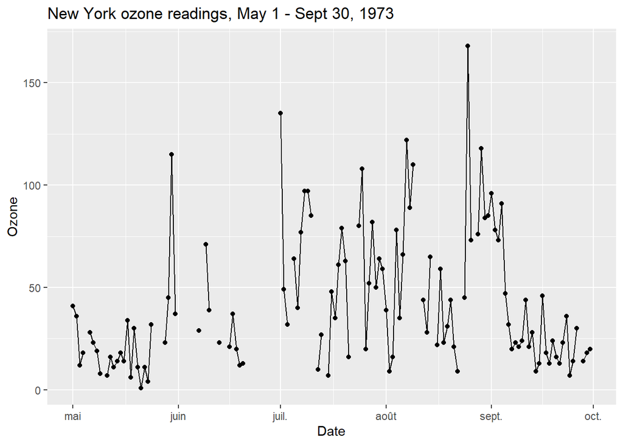

```r
ggplot(airquality_with_date,aes(x=date, y=Ozone)) +
  geom_line() +
  geom_point() +
  xlab("Date") +
  ggtitle("New York ozone readings, May 1 - Sept 30, 1973")
```

```r
# alernative avec la bibliotheque wrapr (qui fournit l'opérateur %.>%)
library("wrapr")

airquality %.>%
    transform(., date = dmy(datestr(Day,Month,1973))) %.>%
    subset(.,!is.na(Ozone), select = c("Ozone","date")) %.>%
    head(.)
```

```
##   Ozone       date
## 1    41 1973-05-01
## 2    36 1973-05-02
## 3    12 1973-05-03
## 4    18 1973-05-04
## 6    28 1973-05-06
## 7    23 1973-05-07
```

#### 2.1.2 Avec une data.table

```r
library("data.table")

DT_airquality <- as.data.table(airquality)[
                  , date:=dmy(datestr(Day,Month,1973))
                ] [
                  , c("Ozone","date")
                ]
head(DT_airquality)
```

```
##    Ozone       date
## 1:    41 1973-05-01
## 2:    36 1973-05-02
## 3:    12 1973-05-03
## 4:    18 1973-05-04
## 5:    NA 1973-05-05
## 6:    28 1973-05-06
```

#### 2.1.3 Avec dplyr

```r
library("dplyr")

airquality_with_date2 <- airquality %>%
        mutate(.,date=dmy(datestr(Day,Month,1973))) %>%
        select(.,Ozone,date)

head(airquality_with_date2)
```

```
##   Ozone       date
## 1    41 1973-05-01
## 2    36 1973-05-02
## 3    12 1973-05-03
## 4    18 1973-05-04
## 5    NA 1973-05-05
## 6    28 1973-05-06
```

### 2.2 Remplacement des NA par la précédente valeur renseignée : na.locf()

#### 2.2.1 Avec les méthodes de base en R

```r
library(zoo)

airquality_corrected <- airquality_with_date

#ATTENTION : ne pas oublier na.rm=false
airquality_corrected$OzoneCorrected <-
  na.locf(airquality_corrected$Ozone,na.rm=FALSE)

summary(airquality_corrected)
```

```
##      Ozone             date            OzoneCorrected
##  Min.   :  1.00   Min.   :1973-05-01   Min.   :  1.00
##  1st Qu.: 18.00   1st Qu.:1973-06-08   1st Qu.: 16.00
##  Median : 31.50   Median :1973-07-16   Median : 30.00
##  Mean   : 42.13   Mean   :1973-07-16   Mean   : 39.78
##  3rd Qu.: 63.25   3rd Qu.:1973-08-23   3rd Qu.: 52.00
##  Max.   :168.00   Max.   :1973-09-30   Max.   :168.00
##  NA's   :37
```

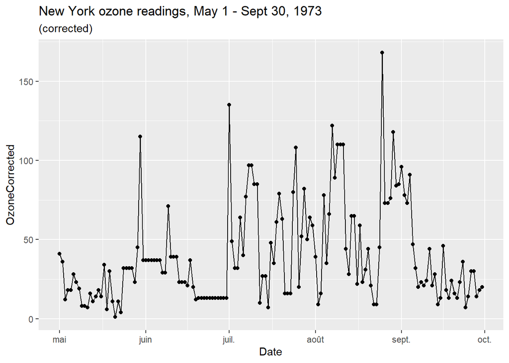

```r
ggplot(airquality_corrected,aes(x=date,y=OzoneCorrected)) +
  geom_point() +
  geom_line()+
  ggtitle("New York ozone readings, May 1 - Sept 30, 1973",
    subtitle = "(corrected)") +
  xlab("Date")
```

#### 2.2.2 Avec une data.table

```r
library("data.table")
library("zoo")

DT_airquality[,OzoneCorrected:=na.locf(Ozone,na.rM=FALSE)]

summary(DT_airquality)
```

```
##      Ozone             date            OzoneCorrected
##  Min.   :  1.00   Min.   :1973-05-01   Min.   :  1.00
##  1st Qu.: 18.00   1st Qu.:1973-06-08   1st Qu.: 16.00
##  Median : 31.50   Median :1973-07-16   Median : 30.00
##  Mean   : 42.13   Mean   :1973-07-16   Mean   : 39.78
##  3rd Qu.: 63.25   3rd Qu.:1973-08-23   3rd Qu.: 52.00
##  Max.   :168.00   Max.   :1973-09-30   Max.   :168.00
##  NA's   :37
```

#### 2.2.3 Avec dplyr

```r
library("dplyr")

airquality_with_date2 %>%
  mutate(.,OzoneCorrected=na.locf(Ozone,na.rM=FALSE)) %>%
  summary(.)
```

```
##      Ozone             date            OzoneCorrected
##  Min.   :  1.00   Min.   :1973-05-01   Min.   :  1.00
##  1st Qu.: 18.00   1st Qu.:1973-06-08   1st Qu.: 16.00
##  Median : 31.50   Median :1973-07-16   Median : 30.00
##  Mean   : 42.13   Mean   :1973-07-16   Mean   : 39.78
##  3rd Qu.: 63.25   3rd Qu.:1973-08-23   3rd Qu.: 52.00
##  Max.   :168.00   Max.   :1973-09-30   Max.   :168.00
##  NA's   :37
```

### 2.3 Renommage et suppression de colonnes

```r
d <- data.frame(x = 1:2, y = 3:4)
print(d)
```

```
##   x y
## 1 1 3
## 2 2 4
```

```r
# renommage des colonnes
colnames(d) <- c("BIGX","BIGY")
print(d)
```

```
##   BIGX BIGY
## 1    1    3
## 2    2    4
```

```r
# suppression de colonnes
d$BIGX <- NULL
print(d)
```

```
##   BIGY
## 1    3
## 2    4
```

## 3. Agrégation

### 3.1 Création d’une ligne “summary”

```r
library(datasets)
library(ggplot2)

head(iris)
```

```
##   Sepal.Length Sepal.Width Petal.Length Petal.Width Species
## 1          5.1         3.5          1.4         0.2  setosa
## 2          4.9         3.0          1.4         0.2  setosa
## 3          4.7         3.2          1.3         0.2  setosa
## 4          4.6         3.1          1.5         0.2  setosa
## 5          5.0         3.6          1.4         0.2  setosa
## 6          5.4         3.9          1.7         0.4  setosa
```

#### 3.1.1 Avec les méthodes de base en R

```r
library(ggplot2)

iris_summary <- aggregate(
  cbind(Petal.Length,Petal.Width) ~ Species,
  data = iris,
  FUN = mean
)

print(iris_summary)
```

```
##      Species Petal.Length Petal.Width
## 1     setosa        1.462       0.246
## 2 versicolor        4.260       1.326
## 3  virginica        5.552       2.026
```

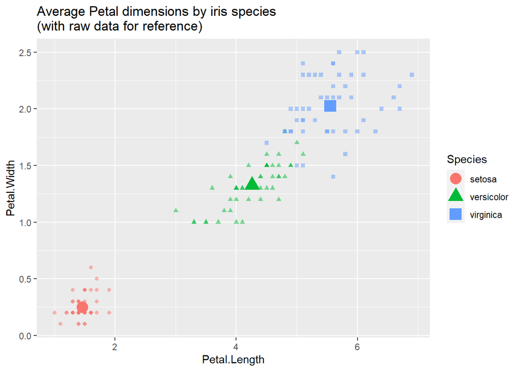

```r
ggplot(mapping = aes(x = Petal.Length, y = Petal.Width,
       shape = Species, color = Species )) +
  geom_point(data = iris, alpha =0.5) +
  geom_point(data = iris_summary, size=5) +
  ggtitle("Average Petal dimensions by iris species\n(with raw data for reference)")
```

#### 3.1.2 Avec une data.table

```r
iris_data.table <- as.data.table(iris)
iris_data.table <- iris_data.table[,
                                   .(Petal.Length = mean(Petal.Length),
                                     Petal.Width = mean(Petal.Width)),
                                   by=.(Species)]
# print(iris_data.table)
```

#### 3.1.3 Avec dplyr

```r
library(dplyr)

iris_summary <- iris %>% group_by(., Species) %>%
                    summarize(.,
                              Petal.Length = mean(Petal.Length),
                              Petal.Width = mean(Petal.Width)) %>%
                    ungroup(.)
#print(iris_summary)
```

#### 3.1.4 Window functions

```r
# base R
# ------------------------------------------
iris_copy <- iris
iris_copy$mean_Petal.Length <- ave(iris_copy$Petal.Length,iris$Species,FUN = mean)
iris_copy$mean_Petal.Width <- ave(iris_copy$Petal.Width,iris$Species,FUN = mean)
#head(iris_copy)
#tail(iris_copy)

# data.table
# ------------------------------------------
library(data.table)

iris_data.table <- as.data.table(iris)
iris_data.table <- iris_data.table[,
                                   `:=`(mean_Petal.Length = mean(Petal.Length),
                                        mean_Petal.Width = mean(Petal.Width)),
                                   by = "Species"]
# print(iris_data.table)

# dplyr
# ------------------------------------------
library(dplyr)

iris_dplyr <- iris %>%
                group_by(.,Species) %>%
                mutate(.,
                       mean_Petal.Length = mean(Petal.Length),
                       mean_Petal.Width = mean(Petal.Width)) %>%
                ungroup(.)
head(iris_dplyr)
```

```
## # A tibble: 6 x 7
##   Sepal.Length Sepal.Width Petal.Length Petal.Width Species mean_Petal.Leng~
##          <dbl>       <dbl>        <dbl>       <dbl> <fct>              <dbl>
## 1          5.1         3.5          1.4         0.2 setosa              1.46
## 2          4.9         3            1.4         0.2 setosa              1.46
## 3          4.7         3.2          1.3         0.2 setosa              1.46
## 4          4.6         3.1          1.5         0.2 setosa              1.46
## 5          5           3.6          1.4         0.2 setosa              1.46
## 6          5.4         3.9          1.7         0.4 setosa              1.46
## # ... with 1 more variable: mean_Petal.Width <dbl>
```

## 4. Combinaison de dataframes

### 4.1 Concaténation (lignes/colonnes) et scission de dataframes

```r
productTable <- wrapr::build_frame(
                "productID", "price" |
                "p1" , 9.99 |
                "p2" , 16.29 |
                "p3" , 19.99 |
                "p4" , 5.49 |
                "p5" , 24.49 )

salesTable <- wrapr::build_frame(
                "productID", "sold_store", "sold_online" |
                "p1" , 6 , 64 |
                "p2" , 31 , 1 |
                "p3" , 30 , 23 |
                "p4" , 31 , 67 |
                "p5" , 43 , 51 )

productTable2 <- wrapr::build_frame(
                "productID", "price" |
                "n1" , 25.49 |
                "n2" , 33.99 |
                "n3" , 17.99 )
```

#### 4.1.1 Concaténation des lignes de dataframes

```r
# base R
# ------------------------------------------
rbind_base <- rbind(productTable,productTable2)
str(rbind_base)
```

```
## 'data.frame':    8 obs. of  2 variables:
##  $ productID: chr  "p1" "p2" "p3" "p4" ...
##  $ price    : num  9.99 16.29 19.99 5.49 24.49 ...
```

```r
# data.table
# ------------------------------------------
library(data.table)

rbindlist(list(productTable,productTable2))
```

```
##    productID price
## 1:        p1  9.99
## 2:        p2 16.29
## 3:        p3 19.99
## 4:        p4  5.49
## 5:        p5 24.49
## 6:        n1 25.49
## 7:        n2 33.99
## 8:        n3 17.99
```

```r
# dplyr
# ------------------------------------------
library(dplyr)

bind_rows(list(productTable,productTable2))
```

```
##   productID price
## 1        p1  9.99
## 2        p2 16.29
## 3        p3 19.99
## 4        p4  5.49
## 5        p5 24.49
## 6        n1 25.49
## 7        n2 33.99
## 8        n3 17.99
```

#### 4.1.2 Scission d’un dataframe

```r
# base R
# ------------------------------------------

# on ajoute une colonne pour déterminer la table d'origine
productTable_marked <- productTable
productTable_marked$table <- "productTable"

productTable2_marked <- productTable2
productTable2_marked$table <- "productTable2"

# concaténation des dataframes
rbind_base <- rbind(productTable_marked,productTable2_marked)
rbind_base
```

```
##   productID price         table
## 1        p1  9.99  productTable
## 2        p2 16.29  productTable
## 3        p3 19.99  productTable
## 4        p4  5.49  productTable
## 5        p5 24.49  productTable
## 6        n1 25.49 productTable2
## 7        n2 33.99 productTable2
## 8        n3 17.99 productTable2
```

```r
# scission des dataframes
tables <- split(rbind_base,rbind_base$table)
tables
```

```
## $productTable
##   productID price        table
## 1        p1  9.99 productTable
## 2        p2 16.29 productTable
## 3        p3 19.99 productTable
## 4        p4  5.49 productTable
## 5        p5 24.49 productTable
##
## $productTable2
##   productID price         table
## 6        n1 25.49 productTable2
## 7        n2 33.99 productTable2
## 8        n3 17.99 productTable2
```

```r
# data.table
# ------------------------------------------
library(data.table)

dt <- as.data.table(rbind_base)

#calcul du prix max par goupe
# .BY : variables et valeurs associées définissant le groupe cournat (ex: table=productTable)
# .SD : data.table représentant le groupe donné sans les colonnes de regroupement
f <- function(.BY, .SD) {
  max(.SD$price)
}

dt[, max_price := f(.BY,.SD), by = table]
print(dt)
```

```
##    productID price         table max_price
## 1:        p1  9.99  productTable     24.49
## 2:        p2 16.29  productTable     24.49
## 3:        p3 19.99  productTable     24.49
## 4:        p4  5.49  productTable     24.49
## 5:        p5 24.49  productTable     24.49
## 6:        n1 25.49 productTable2     33.99
## 7:        n2 33.99 productTable2     33.99
## 8:        n3 17.99 productTable2     33.99
```

```r
# alternative :
dt <- as.data.table(rbind_base)
grouping_column <- "table"
dt[,max_prixe:=max(price),by=grouping_column]
print(dt)
```

```
##    productID price         table max_prixe
## 1:        p1  9.99  productTable     24.49
## 2:        p2 16.29  productTable     24.49
## 3:        p3 19.99  productTable     24.49
## 4:        p4  5.49  productTable     24.49
## 5:        p5 24.49  productTable     24.49
## 6:        n1 25.49 productTable2     33.99
## 7:        n2 33.99 productTable2     33.99
## 8:        n3 17.99 productTable2     33.99
```

```r
# dplyr
# ------------------------------------------
rbind_base %>% group_by(.,table) %>%
              mutate(.,max_price=max(price)) %>%
              ungroup(.)
```

```
## # A tibble: 8 x 4
##   productID price table         max_price
##   <chr>     <dbl> <chr>             <dbl>
## 1 p1         9.99 productTable       24.5
## 2 p2        16.3  productTable       24.5
## 3 p3        20.0  productTable       24.5
## 4 p4         5.49 productTable       24.5
## 5 p5        24.5  productTable       24.5
## 6 n1        25.5  productTable2      34.0
## 7 n2        34.0  productTable2      34.0
## 8 n3        18.0  productTable2      34.0
```

#### 4.1.3 Ajout de colonnes

```r
# base R
# ------------------------------------------
cbind(productTable,salesTable[,-1])
```

```
##   productID price sold_store sold_online
## 1        p1  9.99          6          64
## 2        p2 16.29         31           1
## 3        p3 19.99         30          23
## 4        p4  5.49         31          67
## 5        p5 24.49         43          51
```

```r
# data.table
# ------------------------------------------
library(data.table)

cbind(as.data.table(productTable),
    as.data.table(salesTable[, -1]))
```

```
##    productID price sold_store sold_online
## 1:        p1  9.99          6          64
## 2:        p2 16.29         31           1
## 3:        p3 19.99         30          23
## 4:        p4  5.49         31          67
## 5:        p5 24.49         43          51
```

```r
# dplyr
# ------------------------------------------
library(dplyr)

bind_cols(productTable,salesTable[,-1])
```

```
##   productID price sold_store sold_online
## 1        p1  9.99          6          64
## 2        p2 16.29         31           1
## 3        p3 19.99         30          23
## 4        p4  5.49         31          67
## 5        p5 24.49         43          51
```

### 4.2 Jointures de dataframes

```r
productTable <- wrapr::build_frame(
    "productID", "price" |
    "p1" , 9.99 |
    "p3" , 19.99 |
    "p4" , 5.49 |
    "p5" , 24.49 )
salesTable <- wrapr::build_frame(
    "productID", "unitsSold" |
    "p1" , 10 |
    "p2" , 43 |
    "p3" , 55 |
    "p4" , 8 )
```

#### 4.2.1 Jointure à gauche

```r
# base R
# ------------------------------------------
merge(productTable,salesTable,by="productID",all.x=TRUE)
```

```
##   productID price unitsSold
## 1        p1  9.99        10
## 2        p3 19.99        55
## 3        p4  5.49         8
## 4        p5 24.49        NA
```

```r
# alternative
joined_table <- productTable
joined_table$unitsSold <- salesTable$unitsSold[match(joined_table$productID,
                                                     salesTable$productID)]
print(joined_table)
```

```
##   productID price unitsSold
## 1        p1  9.99        10
## 2        p3 19.99        55
## 3        p4  5.49         8
## 4        p5 24.49        NA
```

```r
# data.table
# ------------------------------------------
library(data.table)

productTable_data.table <- as.data.table(productTable)
salesTable_data.table <- as.data.table(salesTable)

salesTable_data.table[productTable_data.table,on="productID"]
```

```
##    productID unitsSold price
## 1:        p1        10  9.99
## 2:        p3        55 19.99
## 3:        p4         8  5.49
## 4:        p5        NA 24.49
```

```r
# alternative
merge(productTable_data.table, salesTable_data.table,
  by = "productID", all.x = TRUE)
```

```
##    productID price unitsSold
## 1:        p1  9.99        10
## 2:        p3 19.99        55
## 3:        p4  5.49         8
## 4:        p5 24.49        NA
```

```r
# dplyr
# ------------------------------------------
library(dplyr)

left_join(productTable,salesTable,by="productID")
```

```
##   productID price unitsSold
## 1        p1  9.99        10
## 2        p3 19.99        55
## 3        p4  5.49         8
## 4        p5 24.49        NA
```

#### 4.2.2 Jointure interne

```r
# base R
# ------------------------------------------
merge(productTable,salesTable,by="productID")
```

```
##   productID price unitsSold
## 1        p1  9.99        10
## 2        p3 19.99        55
## 3        p4  5.49         8
```

```r
# data.table
# ------------------------------------------
library(data.table)

productTable_data.table <- as.data.table(productTable)
salesTable_data.table <- as.data.table(salesTable)

merge(productTable,salesTable,by="productID")
```

```
##   productID price unitsSold
## 1        p1  9.99        10
## 2        p3 19.99        55
## 3        p4  5.49         8
```

```r
# dplyr
# ------------------------------------------
library(dplyr)

inner_join(productTable,salesTable,by="productID")
```

```
##   productID price unitsSold
## 1        p1  9.99        10
## 2        p3 19.99        55
## 3        p4  5.49         8
```

#### 4.2.3 Jointure externe

```r
# base R
# ------------------------------------------
merge(productTable,salesTable,by="productID",all=TRUE)
```

```
##   productID price unitsSold
## 1        p1  9.99        10
## 2        p2    NA        43
## 3        p3 19.99        55
## 4        p4  5.49         8
## 5        p5 24.49        NA
```

```r
# data.table
# ------------------------------------------
library(data.table)

productTable_data.table <- as.data.table(productTable)
salesTable_data.table <- as.data.table(salesTable)

merge(productTable,salesTable,by="productID",all=TRUE)
```

```
##   productID price unitsSold
## 1        p1  9.99        10
## 2        p2    NA        43
## 3        p3 19.99        55
## 4        p4  5.49         8
## 5        p5 24.49        NA
```

```r
# dplyr
# ------------------------------------------
library(dplyr)

full_join(productTable,salesTable,by="productID")
```

```
##   productID price unitsSold
## 1        p1  9.99        10
## 2        p3 19.99        55
## 3        p4  5.49         8
## 4        p5 24.49        NA
## 5        p2    NA        43
```

#### 4.2.4 Rolling join (data.tables)

On emploie Un rolling join quand la jointure doit être faite sur une date pour laquelle il n’y a pas de correspondance exacte entre les data.tables à grouper.

Ex: achat/vente à 2018-10-18 02:13:42 d’une action dont le prix a été fixé à 2018-10-18 2:12:23/

```r
library(data.table)

quotes <- data.table(
  bid = c(5, 5, 7, 8),
  ask = c(6, 6, 8, 10),
  bid_quantity = c(100, 100, 100, 100),
  ask_quantity = c(100, 100, 100, 100),
  when = as.POSIXct(strptime(
    c("2018-10-18 1:03:17",
      "2018-10-18 2:12:23",
      "2018-10-18 2:15:00",
      "2018-10-18 2:17:51"),
      "%Y-%m-%d %H:%M:%S")))

print(quotes)
```

```
##    bid ask bid_quantity ask_quantity                when
## 1:   5   6          100          100 2018-10-18 01:03:17
## 2:   5   6          100          100 2018-10-18 02:12:23
## 3:   7   8          100          100 2018-10-18 02:15:00
## 4:   8  10          100          100 2018-10-18 02:17:51
```

```r
trades <- data.table(
  trade_id = c(32525, 32526),
  price = c(5.5, 9),
  quantity = c(100, 200),
  when = as.POSIXct(strptime(
    c("2018-10-18 2:13:42",
      "2018-10-18 2:19:20"),
      "%Y-%m-%d %H:%M:%S")))

print(trades)
```

```
##    trade_id price quantity                when
## 1:    32525   5.5      100 2018-10-18 02:13:42
## 2:    32526   9.0      200 2018-10-18 02:19:20
```

```r
quotes[, quote_time := when]
trades[ , trade_time := when ]

quotes[ trades, on = "when", roll = TRUE ][
    , .(quote_time, bid, price, ask, trade_id, trade_time) ]
```

```
##             quote_time bid price ask trade_id          trade_time
## 1: 2018-10-18 02:12:23   5   5.5   6    32525 2018-10-18 02:13:42
## 2: 2018-10-18 02:17:51   8   9.0  10    32526 2018-10-18 02:19:20
```

## 5. Changement de forme

### 5.1 Transformation de colonnes en lignes

Exemple : dataset présentant le nombre de blessé graves / tués lors d’accident de voiture avant/après l’obligation du port de la ceinture de sécurité

```r
library(datasets)
library(xts)

# le script ci-dessous utilise un format de date anglais
Sys.setlocale("LC_ALL","English")
```

```
## [1] "LC_COLLATE=English_United States.1252;LC_CTYPE=English_United States.1252;LC_MONETARY=English_United States.1252;LC_NUMERIC=C;LC_TIME=English_United States.1252"
```

```r
# transorme l'index des dates en colonne
dates <- index(as.xts(time(Seatbelts)))
Seatbelts <- data.frame(Seatbelts)
Seatbelts$date <- dates

# restreint les données à 1982 et 1983
Seatbelts <- Seatbelts[ (Seatbelts$date >= as.yearmon("Jan 1982")) &
                        (Seatbelts$date <= as.yearmon("Dec 1983")),
                        , drop = FALSE]
Seatbelts$date <- as.Date(Seatbelts$date)

# indique si la loi sur la ceinture de sécurité était appliquée
Seatbelts$law <- ifelse(Seatbelts$law==1, "new law", "pre-law")

# sélection des colonnes
Seatbelts <- Seatbelts[, c("date", "DriversKilled", "front", "rear", "law")]
head(Seatbelts)
```

```
##           date DriversKilled front rear     law
## 157 1982-01-01           115   595  238 pre-law
## 158 1982-02-01           104   673  285 pre-law
## 159 1982-03-01           131   660  324 pre-law
## 160 1982-04-01           108   676  346 pre-law
## 161 1982-05-01           103   755  410 pre-law
## 162 1982-06-01           115   815  411 pre-law
```

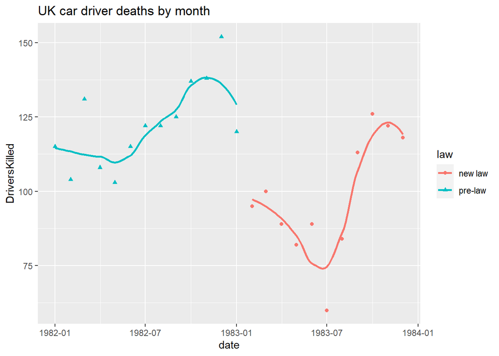

```r
# A partir de ce dataset, le but est de voir comment le port de la ceinture de sécurité
# sauve des vies. Le graphique que l'on a en tête est celui-ci :

library("ggplot2")
ggplot(Seatbelts,aes(x=date,y=DriversKilled,color=law,shape=law))+
  geom_point()+
  geom_smooth(se=FALSE) +
  ggtitle("UK car driver deaths by month")
```

```r
#
```

Dans le dataset ci-dessus, une ligne contient différentes positions des voyageurs :

- conducteur (DriversKilled)
- passager assis à l’avant (front)
- passager assis à l’arrière (rear)

On souhait qu’une ligne ne contienne qu’un seul type de position ce qui implique de dédoubler les enregistrements.

#### 5.1.1 Solution 1: data.table::melt.data.table()

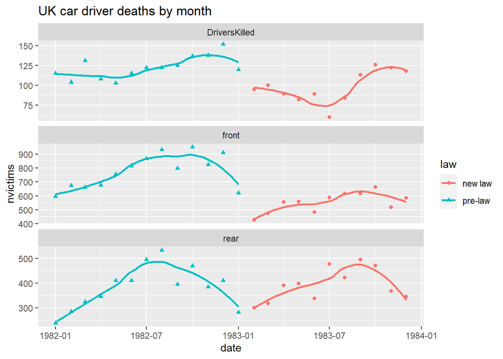

```r
library(data.table)

Seatbelts_long1 <- melt.data.table(as.data.table(Seatbelts),
                                   id.vars = NULL,
                                   measure.vars = c("DriversKilled","front","rear"),
                                   variable.name="victim_type",
                                   value.name="nvictims")

ggplot(Seatbelts_long1,aes(x=date,y=nvictims,color=law,shape=law))+
  geom_point()+
  geom_smooth(se=FALSE) +
  facet_wrap(~victim_type, ncol=1, scale="free_y") +
  ggtitle("UK car driver deaths by month")
```

#### 5.1.2 Solution 2: cdata::unpivot_to_blocks()

```r
library(cdata)

Seatbelts_long2 <- unpivot_to_blocks(Seatbelts,
                      nameForNewKeyColumn="victim_type",
                      nameForNewValueColumn="nvictims",
                      columnsToTakeFrom=c("DriversKilled","front","rear"))
```

#### 5.1.3 Solution 3: tidyr::gather()

```r
library(tidyr)

Seatbelts_long3 <- gather(Seatbelts,
                      key="victim_type",
                      value="nvictims",
                      DriversKilled,front,rear)

head(Seatbelts_long3)
```

```
##         date     law   victim_type nvictims
## 1 1982-01-01 pre-law DriversKilled      115
## 2 1982-02-01 pre-law DriversKilled      104
## 3 1982-03-01 pre-law DriversKilled      131
## 4 1982-04-01 pre-law DriversKilled      108
## 5 1982-05-01 pre-law DriversKilled      103
## 6 1982-06-01 pre-law DriversKilled      115
```

### 5.2 Transformation de lignes en colonnes

Le but est ici de représenter ici l’ensemble des informations concernant un poussin sur une seule ligne. Dans le data.frame original, il y a une information par ligne.

```r
library("datasets")
library("data.table")
library("ggplot2")

ChickWeight <- data.frame(ChickWeight) # enlève les attributs
ChickWeight$Diet <- NULL # envève la colonne "Diet"

# préfixe les ids par des 0, pour que toutes les chaines de caractères coresspondnates aient la même taille
padz <- function(x, n=max(nchar(x))) gsub(" ", "0", formatC(x, width=n))
# ajoute "Chick" aux ids des poussins
ChickWeight$Chick <- paste0("Chick", padz(as.character(ChickWeight$Chick)))

head(ChickWeight)
```

```
##   weight Time   Chick
## 1     42    0 Chick01
## 2     51    2 Chick01
## 3     59    4 Chick01
## 4     64    6 Chick01
## 5     76    8 Chick01
## 6     93   10 Chick01
```

```r
# agregation ;  count (nbre de poussins ayant survécu à une date donnée) et weight (poids moyen)
ChickSummary <- as.data.table(ChickWeight)
ChickSummary <- ChickSummary[,
                .(count = .N,
                weight = mean(weight),
                q1_weight = quantile(weight, probs = 0.25),
                q2_weight = quantile(weight, probs = 0.75)),
                by = Time]
head(ChickSummary)
```

```
##    Time count    weight q1_weight q2_weight
## 1:    0    50  41.06000        41        42
## 2:    2    50  49.22000        48        51
## 3:    4    49  59.95918        57        63
## 4:    6    49  74.30612        68        80
## 5:    8    49  91.24490        83       102
## 6:   10    49 107.83673        93       124
```

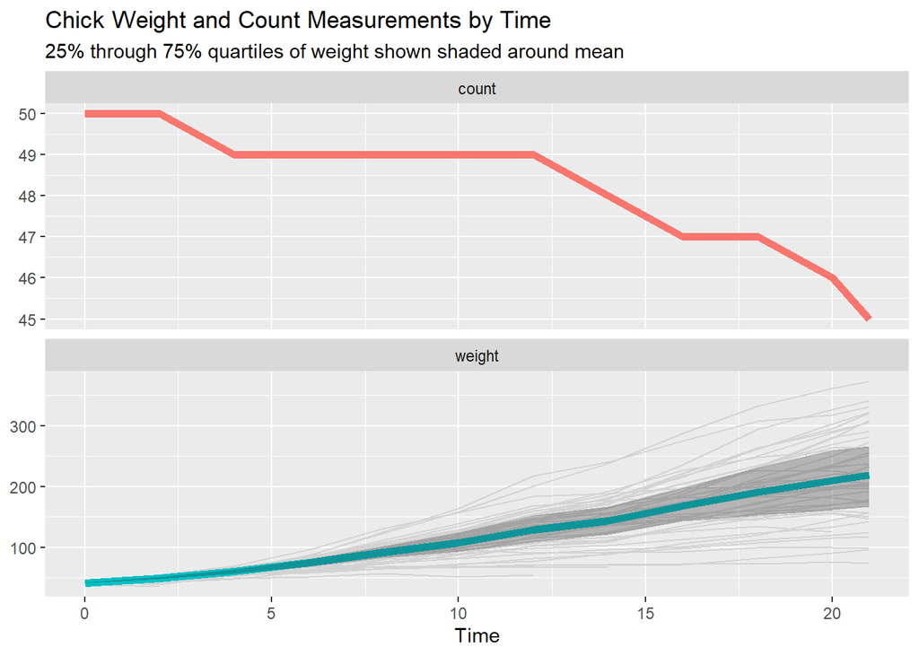

```r
# Réprésentation graphique
# ------------------------
library("ggplot2")
ChickSummary <- cdata::unpivot_to_blocks(
                  ChickSummary,
                  nameForNewKeyColumn = "measurement",
                  nameForNewValueColumn = "value",
                  columnsToTakeFrom = c("count", "weight"))



ChickSummary$q1_weight[ChickSummary$measurement=="count"] <- NA
ChickSummary$q2_weight[ChickSummary$measurement=="count"] <- NA

CW <- ChickWeight
CW$measurement <- "weight"

ggplot(ChickSummary, aes(x = Time, y = value, color = measurement)) +
        geom_line(data = CW, aes(x = Time, y = weight, group = Chick), color="LightGray") +
        geom_line(size=2) +
        geom_ribbon(aes(ymin = q1_weight, ymax = q2_weight),
            alpha = 0.3, colour = NA) +
        facet_wrap(~measurement, ncol=1, scales = "free_y") +
        theme(legend.position = "none") +
        ylab(NULL) +
        ggtitle("Chick Weight and Count Measurements by Time",
        subtitle = "25% through 75% quartiles of weight shown shaded around mean")
```

#### 5.2.1 Solution 1: data.table::dcast.data.table()

```r
library(data.table)

ChickWeight_wide1 <- dcast.data.table(as.data.table(ChickWeight),
                                      Chick ~ Time,
                                      value.var = "weight")
head(ChickWeight_wide1)
```

```
##      Chick  0  2  4  6  8  10  12  14  16  18  20  21
## 1: Chick01 42 51 59 64 76  93 106 125 149 171 199 205
## 2: Chick02 40 49 58 72 84 103 122 138 162 187 209 215
## 3: Chick03 43 39 55 67 84  99 115 138 163 187 198 202
## 4: Chick04 42 49 56 67 74  87 102 108 136 154 160 157
## 5: Chick05 41 42 48 60 79 106 141 164 197 199 220 223
## 6: Chick06 41 49 59 74 97 124 141 148 155 160 160 157
```

#### 5.2.2 Solution 2: cdata::pivot_to_rowrecs()

```r
library("cdata")

ChickWeight_wide2 <- pivot_to_rowrecs(
                        ChickWeight,
                        columnToTakeKeysFrom = "Time",
                        columnToTakeValuesFrom = "weight",
                        rowKeyColumns = "Chick")
```

#### 5.2.3 Solution 3: tidyr::spread()

```r
library("tidyr")

ChickWeight_wide3 <- spread(ChickWeight,
                            key = Time,
                            value = weight)

head(ChickWeight_wide1)
```

```
##      Chick  0  2  4  6  8  10  12  14  16  18  20  21
## 1: Chick01 42 51 59 64 76  93 106 125 149 171 199 205
## 2: Chick02 40 49 58 72 84 103 122 138 162 187 209 215
## 3: Chick03 43 39 55 67 84  99 115 138 163 187 198 202
## 4: Chick04 42 49 56 67 74  87 102 108 136 154 160 157
## 5: Chick05 41 42 48 60 79 106 141 164 197 199 220 223
## 6: Chick06 41 49 59 74 97 124 141 148 155 160 160 157
```